# Following the CRISP-DM process, lets first understand the Business Problem that we want to address.

[output not shown]

# # 1. So we would look at the data to understand it and subsequently move ahead with the process as per CRISP-DM

Lets first take a ook at the data and understand it. So now moving on to the 2nd process of CRISP-DM lets understand the data and move on to 3rd process of data Pre-processing and Visualising.

```python
# Import the required libraries
import pandas as pd
import numpy as np
import matplotlib.pyplot as plt
import seaborn as sns
import warnings
import calendar
from re import sub
warnings.filterwarnings("ignore")
%matplotlib inline
```

# Lets import the datasets first and perform Exploratory analysis

```python
s_cal= pd.read_csv('seattle_calendar.csv',parse_dates=['date'])
s_lst= pd.read_csv('seattle_listings.csv')
s_revws= pd.read_csv('seattle_reviews.csv')
```

```python
s_lst.head()
```

|  | id | listing_url | scrape_id | last_scraped | name | summary | space | description | experiences_offered | neighborhood_overview | ... | review_scores_value | requires_license | license | jurisdiction_names | instant_bookable | cancellation_policy | require_guest_profile_picture | require_guest_phone_verification | calculated_host_listings_count | reviews_per_month |
| --- | --- | --- | --- | --- | --- | --- | --- | --- | --- | --- | --- | --- | --- | --- | --- | --- | --- | --- | --- | --- | --- |
| 0 | 241032 | https://www.airbnb.com/rooms/241032 | 20160104002432 | 2016-01-04 | Stylish Queen Anne Apartment | NaN | Make your self at home in this charming one-be... | Make your self at home in this charming one-be... | none | NaN | ... | 10.0 | f | NaN | WASHINGTON | f | moderate | f | f | 2 | 4.07 |
| 1 | 953595 | https://www.airbnb.com/rooms/953595 | 20160104002432 | 2016-01-04 | Bright & Airy Queen Anne Apartment | Chemically sensitive? We've removed the irrita... | Beautiful, hypoallergenic apartment in an extr... | Chemically sensitive? We've removed the irrita... | none | Queen Anne is a wonderful, truly functional vi... | ... | 10.0 | f | NaN | WASHINGTON | f | strict | t | t | 6 | 1.48 |
| 2 | 3308979 | https://www.airbnb.com/rooms/3308979 | 20160104002432 | 2016-01-04 | New Modern House-Amazing water view | New modern house built in 2013. Spectacular s... | Our house is modern, light and fresh with a wa... | New modern house built in 2013. Spectacular s... | none | Upper Queen Anne is a charming neighborhood fu... | ... | 10.0 | f | NaN | WASHINGTON | f | strict | f | f | 2 | 1.15 |
| 3 | 7421966 | https://www.airbnb.com/rooms/7421966 | 20160104002432 | 2016-01-04 | Queen Anne Chateau | A charming apartment that sits atop Queen Anne... | NaN | A charming apartment that sits atop Queen Anne... | none | NaN | ... | NaN | f | NaN | WASHINGTON | f | flexible | f | f | 1 | NaN |
| 4 | 278830 | https://www.airbnb.com/rooms/278830 | 20160104002432 | 2016-01-04 | Charming craftsman 3 bdm house | Cozy family craftman house in beautiful neighb... | Cozy family craftman house in beautiful neighb... | Cozy family craftman house in beautiful neighb... | none | We are in the beautiful neighborhood of Queen ... | ... | 9.0 | f | NaN | WASHINGTON | f | strict | f | f | 1 | 0.89 |

5 rows × 92 columns

```python
s_revws.head()
```

|  | listing_id | id | date | reviewer_id | reviewer_name | comments |
| --- | --- | --- | --- | --- | --- | --- |
| 0 | 7202016 | 38917982 | 2015-07-19 | 28943674 | Bianca | Cute and cozy place. Perfect location to every... |
| 1 | 7202016 | 39087409 | 2015-07-20 | 32440555 | Frank | Kelly has a great room in a very central locat... |
| 2 | 7202016 | 39820030 | 2015-07-26 | 37722850 | Ian | Very spacious apartment, and in a great neighb... |
| 3 | 7202016 | 40813543 | 2015-08-02 | 33671805 | George | Close to Seattle Center and all it has to offe... |
| 4 | 7202016 | 41986501 | 2015-08-10 | 34959538 | Ming | Kelly was a great host and very accommodating ... |

```python
s_cal.head()
```

|  | listing_id | date | available | price |
| --- | --- | --- | --- | --- |
| 0 | 241032 | 2016-01-04 | t | $85.00 |
| 1 | 241032 | 2016-01-05 | t | $85.00 |
| 2 | 241032 | 2016-01-06 | f | NaN |
| 3 | 241032 | 2016-01-07 | f | NaN |
| 4 | 241032 | 2016-01-08 | f | NaN |

A look at the Listing dataset and and we see, a lot of Features and most of them do not look relevent to our project. Lets just create a new dataframe with only the selected relevent columns.

```python
s_lst.columns
```

```
Index(['id', 'listing_url', 'scrape_id', 'last_scraped', 'name', 'summary',
       'space', 'description', 'experiences_offered', 'neighborhood_overview',
       'notes', 'transit', 'thumbnail_url', 'medium_url', 'picture_url',
       'xl_picture_url', 'host_id', 'host_url', 'host_name', 'host_since',
       'host_location', 'host_about', 'host_response_time',
       'host_response_rate', 'host_acceptance_rate', 'host_is_superhost',
       'host_thumbnail_url', 'host_picture_url', 'host_neighbourhood',
       'host_listings_count', 'host_total_listings_count',
       'host_verifications', 'host_has_profile_pic', 'host_identity_verified',
       'street', 'neighbourhood', 'neighbourhood_cleansed',
       'neighbourhood_group_cleansed', 'city', 'state', 'zipcode', 'market',
       'smart_location', 'country_code', 'country', 'latitude', 'longitude',
       'is_location_exact', 'property_type', 'room_type', 'accommodates',
       'bathrooms', 'bedrooms', 'beds', 'bed_type', 'amenities', 'square_feet',
       'price', 'weekly_price', 'monthly_price', 'security_deposit',
       'cleaning_fee', 'guests_included', 'extra_people', 'minimum_nights',
       'maximum_nights', 'calendar_updated', 'has_availability',
       'availability_30', 'availability_60', 'availability_90',
       'availability_365', 'calendar_last_scraped', 'number_of_reviews',
       'first_review', 'last_review', 'review_scores_rating',
       'review_scores_accuracy', 'review_scores_cleanliness',
       'review_scores_checkin', 'review_scores_communication',
       'review_scores_location', 'review_scores_value', 'requires_license',
       'license', 'jurisdiction_names', 'instant_bookable',
       'cancellation_policy', 'require_guest_profile_picture',
       'require_guest_phone_verification', 'calculated_host_listings_count',
       'reviews_per_month'],
      dtype='object')
```

We see a lot of columns in the listing dataset and most of them we can make out, do not contribute to our objective, hence can be droped straight up. So lets just pickup columns that are of interest

```python
listings= pd.DataFrame(s_lst[['id','host_is_superhost',
      'neighbourhood', 'property_type',
       'room_type', 'accommodates', 'bathrooms', 'bedrooms','amenities', 'price',
        'number_of_reviews', 'review_scores_rating',
         'cancellation_policy',
       'reviews_per_month','neighbourhood_group_cleansed']])
```

```python
# Check the proption of NaN's in the price column
pd.isnull(s_cal).sum()/len(s_cal)*100
```

```
listing_id     0.000000
date           0.000000
available      0.000000
price         32.938998
dtype: float64
```

```python
# Find the range of time the data has been taken over
print(pd.to_datetime(s_cal['date']).min())
print(pd.to_datetime(s_cal['date']).max())
```

```
2016-01-04 00:00:00
2017-01-02 00:00:00
```

```python
# Check the number of days data has been collected for
len(s_cal.date.unique())
```

```
365
```

We should now be looking to clean the data and make sure all features have the correct data type  
Let us see the Null values composition for both Listings and calander dataset

```python
def get_null_col(df):
    """Identify columns that have missing data in the dataframe

    Args:
        df: input dataframe to identify missing data

    Returns:
        df: dataframe of column names as index, # missing records, % missing records
    """

    null_col = df.columns[df.isna().sum()>0]
    col_null_val = df[null_col].isna().sum().sort_values(ascending=False)
    per_null_val = (df[null_col].isna().sum()/df.shape[0]*100).sort_values(ascending=False)
    nulls_df = pd.DataFrame(col_null_val,columns=['#Nulls'])
    nulls_df['%Nulls']=per_null_val
    print('Number of columns with missing data:',nulls_df.shape[0])
    return nulls_df

get_null_col(listings)
```

```
Number of columns with missing data: 7
```

|  | #Nulls | %Nulls |
| --- | --- | --- |
| review_scores_rating | 647 | 16.946045 |
| reviews_per_month | 627 | 16.422211 |
| neighbourhood | 416 | 10.895757 |
| bathrooms | 16 | 0.419068 |
| bedrooms | 6 | 0.157150 |
| host_is_superhost | 2 | 0.052383 |
| property_type | 1 | 0.026192 |

As per the above findings,  
we can drop review_score_rating as we have reviews_per_month  
we can drop neighbourhood as we have neighbourhood_cleansed, which is a better depiction of neighbourhood  
bathroom, bedroom and host_is_superhost and property_type can be imputed with the mode

```python
listings.drop(['review_scores_rating','neighbourhood'], axis=1, inplace=True)
```

```python
mode= listings.filter(['bathrooms','bedrooms','host_is_superhost','property_type']).mode()
col= ['bathrooms','bedrooms','host_is_superhost','property_type']
listings[col]=listings[col].fillna(listings.mode().iloc[0])
```

Now lets look at the distribution of reviews_per_month and see if mean or median, which one is better for imputation

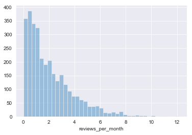

```python
sns.distplot(listings['reviews_per_month'], kde=False)
plt.show()
```

As data is Right Skewed hence median is a better measure for imputation

```python
listings['reviews_per_month'].fillna((listings['reviews_per_month'].median()), inplace= True)
```

```python
listings.head()
```

|  | id | host_is_superhost | property_type | room_type | accommodates | bathrooms | bedrooms | amenities | price | number_of_reviews | cancellation_policy | reviews_per_month | neighbourhood_group_cleansed |
| --- | --- | --- | --- | --- | --- | --- | --- | --- | --- | --- | --- | --- | --- |
| 0 | 241032 | f | Apartment | Entire home/apt | 4 | 1.0 | 1.0 | {TV,"Cable TV",Internet,"Wireless Internet","A... | $85.00 | 207 | moderate | 4.07 | Queen Anne |
| 1 | 953595 | t | Apartment | Entire home/apt | 4 | 1.0 | 1.0 | {TV,Internet,"Wireless Internet",Kitchen,"Free... | $150.00 | 43 | strict | 1.48 | Queen Anne |
| 2 | 3308979 | f | House | Entire home/apt | 11 | 4.5 | 5.0 | {TV,"Cable TV",Internet,"Wireless Internet","A... | $975.00 | 20 | strict | 1.15 | Queen Anne |
| 3 | 7421966 | f | Apartment | Entire home/apt | 3 | 1.0 | 0.0 | {Internet,"Wireless Internet",Kitchen,"Indoor ... | $100.00 | 0 | flexible | 1.54 | Queen Anne |
| 4 | 278830 | f | House | Entire home/apt | 6 | 2.0 | 3.0 | {TV,"Cable TV",Internet,"Wireless Internet",Ki... | $450.00 | 38 | strict | 0.89 | Queen Anne |

We need to remove the $ sign from the price column.

```python
def clean_price(price):
    """Take in a string and return a float without the currency sign"""
    try:
        return float(sub(r'[^\d.]', '', price))
    except:
        return float(price)
listings['price'] = listings['price'].map(clean_price)
s_cal['price'] = s_cal['price'].map(clean_price)
```

```python
s_cal.info()
```

```
<class 'pandas.core.frame.DataFrame'>
RangeIndex: 1393570 entries, 0 to 1393569
Data columns (total 4 columns):
listing_id    1393570 non-null int64
date          1393570 non-null datetime64[ns]
available     1393570 non-null object
price         934542 non-null float64
dtypes: datetime64[ns](1), float64(1), int64(1), object(1)
memory usage: 42.5+ MB
```

```python
# lets process the Calender dataset

#Converting the date column to a datetime
s_cal['date'] = pd.to_datetime( s_cal['date'] )

#Computing the day of week
s_cal['dayofweek'] = s_cal['date'].apply(lambda x: x.day_name())

#Computing the month of the year
s_cal['month'] = s_cal['date'].apply(lambda x: x.month)

#Converting available to a boolean column
s_cal['available'] = s_cal['available'].apply(lambda x: x == 't')
```

```python
s_cal.head()
```

|  | listing_id | date | available | price | dayofweek | month |
| --- | --- | --- | --- | --- | --- | --- |
| 0 | 241032 | 2016-01-04 | True | 85.0 | Monday | 1 |
| 1 | 241032 | 2016-01-05 | True | 85.0 | Tuesday | 1 |
| 2 | 241032 | 2016-01-06 | False | NaN | Wednesday | 1 |
| 3 | 241032 | 2016-01-07 | False | NaN | Thursday | 1 |
| 4 | 241032 | 2016-01-08 | False | NaN | Friday | 1 |

Lets check the availability day of the week level

```python
s_cal.groupby('dayofweek').mean()[['available']]
```

| dayofweek | available |
| --- | --- |
| Friday | 0.668911 |
| Monday | 0.671101 |
| Saturday | 0.667758 |
| Sunday | 0.673001 |
| Thursday | 0.669743 |
| Tuesday | 0.671954 |
| Wednesday | 0.671793 |

not much takeaway from this as no variation can be observed

Lets look at the neighbourhood level

```python
pd.merge(s_cal,listings[['id','neighbourhood_group_cleansed']], left_on = 'listing_id', right_on = 'id').groupby('neighbourhood_group_cleansed').mean().sort_values('available', ascending = False)['available']
```

```
neighbourhood_group_cleansed
Interbay               0.845330
Magnolia               0.774669
Lake City              0.768800
Delridge               0.747182
University District    0.744397
Northgate              0.722774
Beacon Hill            0.702809
West Seattle           0.701127
Ballard                0.692257
Seward Park            0.680012
Central Area           0.672354
Other neighborhoods    0.671685
Rainier Valley         0.670526
Downtown               0.649910
Capitol Hill           0.641048
Queen Anne             0.620423
Cascade                0.576174
Name: available, dtype: float64
```

```python
# Now lets look at day of week variations across neighbourhoods
pd.merge(s_cal,listings[['id','neighbourhood_group_cleansed']], left_on = 'listing_id', right_on = 'id').groupby(['neighbourhood_group_cleansed', 'dayofweek']).mean()['available'].unstack()
```

| dayofweek neighbourhood_group_cleansed | Friday | Monday | Saturday | Sunday | Thursday | Tuesday | Wednesday |
| --- | --- | --- | --- | --- | --- | --- | --- |
| Ballard | 0.685953 | 0.694586 | 0.684365 | 0.693395 | 0.691806 | 0.697241 | 0.698411 |
| Beacon Hill | 0.699153 | 0.703230 | 0.697360 | 0.701923 | 0.704205 | 0.707790 | 0.705997 |
| Capitol Hill | 0.642552 | 0.640378 | 0.641602 | 0.643942 | 0.640144 | 0.639601 | 0.639126 |
| Cascade | 0.572602 | 0.574942 | 0.572169 | 0.576491 | 0.577139 | 0.579948 | 0.579948 |
| Central Area | 0.668022 | 0.675308 | 0.667136 | 0.675005 | 0.672035 | 0.675005 | 0.673911 |
| Delridge | 0.749757 | 0.742298 | 0.750000 | 0.747809 | 0.746592 | 0.746105 | 0.747809 |
| Downtown | 0.646226 | 0.652581 | 0.645646 | 0.655733 | 0.646154 | 0.652721 | 0.650254 |
| Interbay | 0.844406 | 0.843911 | 0.846154 | 0.847902 | 0.844406 | 0.844406 | 0.846154 |
| Lake City | 0.767509 | 0.765981 | 0.764925 | 0.768657 | 0.772962 | 0.767796 | 0.773823 |
| Magnolia | 0.773014 | 0.776059 | 0.773960 | 0.775536 | 0.773644 | 0.775221 | 0.775221 |
| Northgate | 0.720673 | 0.723349 | 0.720433 | 0.724519 | 0.722115 | 0.724760 | 0.723558 |
| Other neighborhoods | 0.671042 | 0.671095 | 0.668233 | 0.672132 | 0.672520 | 0.672714 | 0.674070 |
| Queen Anne | 0.619622 | 0.621298 | 0.619557 | 0.624837 | 0.617536 | 0.620469 | 0.619622 |
| Rainier Valley | 0.667271 | 0.669989 | 0.666062 | 0.673077 | 0.670295 | 0.673682 | 0.673319 |
| Seward Park | 0.679196 | 0.680103 | 0.676573 | 0.680070 | 0.680070 | 0.681381 | 0.682692 |
| University District | 0.744956 | 0.742809 | 0.745113 | 0.747636 | 0.742591 | 0.743380 | 0.744325 |
| West Seattle | 0.700171 | 0.702203 | 0.700265 | 0.703676 | 0.698655 | 0.701686 | 0.701213 |

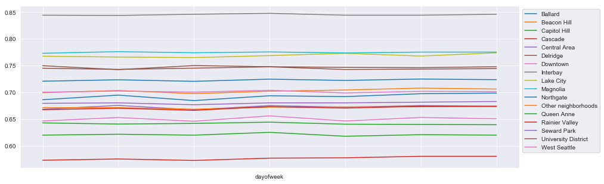

```python
fig, ax = plt.subplots(1,1, figsize =(15,5))
# ax.set_xticks(list(range(1,13)))
pd.merge(s_cal,listings[['id','neighbourhood_group_cleansed']], left_on = 'listing_id', right_on = 'id').groupby(['dayofweek', 'neighbourhood_group_cleansed']).mean()['available'].unstack().plot(ax =ax)
ax.legend(bbox_to_anchor=(1,1), loc="upper left")
```

So this do not show any variation for any neighborhood for any day of the week, it seems consistent

Now lets look at the seasonal variation, first at the city level and then we will move on to the neighborhood level

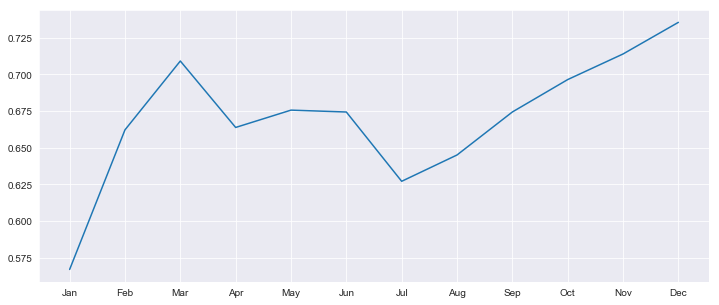

```python
# Seasonal variations

# First we check across the city and then at the neighbourhood level
fig, ax = plt.subplots(1,1, figsize =(12,5))
ax.set_xticks(list(range(1,13)))
ax.set_xticklabels(calendar.month_abbr[1:13])
# ax.set_xticks(['Jan' 'Feb', 'Mar', 'Apr', 'May', 'Jun', 'Jul', 'Aug', 'Sep', 'Oct', 'Nov', 'Dec'])

plt.plot( s_cal.groupby('month').mean().sort_values('month', ascending = True)['available'] )
```

So this is quite interesting as we see availability is very low with a big dip in January and it peaks towards the end of the year. People tent to go on vacation towards the end of the year, hence the peak. Also availability is high in feb and march and again it dips during july. If we try to find the reason for the dip in mid year,then we come to know that this is the time when the city is dry and inflow of people might be low and locals would be moving out of the city.

```python
pd.merge(s_cal, listings[['id','neighbourhood_group_cleansed']], left_on = 'listing_id', right_on = 'id').groupby(['neighbourhood_group_cleansed', 'month']).mean()['available'].unstack()
```

| month neighbourhood_group_cleansed | 1 | 2 | 3 | 4 | 5 | 6 | 7 | 8 | 9 | 10 | 11 | 12 |
| --- | --- | --- | --- | --- | --- | --- | --- | --- | --- | --- | --- | --- |
| Ballard | 0.533043 | 0.613643 | 0.682889 | 0.668551 | 0.701964 | 0.731449 | 0.666199 | 0.700000 | 0.721449 | 0.741094 | 0.761159 | 0.779102 |
| Beacon Hill | 0.596045 | 0.692870 | 0.749043 | 0.720621 | 0.737015 | 0.723729 | 0.650082 | 0.696555 | 0.700847 | 0.705850 | 0.716102 | 0.742482 |
| Capitol Hill | 0.544680 | 0.629326 | 0.661888 | 0.613698 | 0.626842 | 0.641093 | 0.601639 | 0.614781 | 0.653322 | 0.680776 | 0.697942 | 0.724071 |
| Cascade | 0.457678 | 0.557148 | 0.635738 | 0.574532 | 0.592968 | 0.562172 | 0.492207 | 0.512142 | 0.584270 | 0.616890 | 0.644569 | 0.680681 |
| Central Area | 0.532249 | 0.655453 | 0.690532 | 0.641373 | 0.665093 | 0.682023 | 0.646210 | 0.662645 | 0.691689 | 0.707230 | 0.731165 | 0.758808 |
| Delridge | 0.611814 | 0.752510 | 0.770927 | 0.759072 | 0.764394 | 0.772152 | 0.714577 | 0.713761 | 0.754852 | 0.768885 | 0.783122 | 0.798693 |
| Downtown | 0.597925 | 0.707157 | 0.748448 | 0.692704 | 0.681862 | 0.644906 | 0.580158 | 0.593853 | 0.610063 | 0.631102 | 0.644277 | 0.668229 |
| Interbay | 0.833333 | 0.896552 | 0.909091 | 0.821212 | 0.812317 | 0.818182 | 0.809384 | 0.806452 | 0.818182 | 0.818182 | 0.893939 | 0.909091 |
| Lake City | 0.677114 | 0.728770 | 0.801637 | 0.787065 | 0.794896 | 0.788060 | 0.695234 | 0.719788 | 0.768657 | 0.819933 | 0.820896 | 0.820896 |
| Magnolia | 0.744262 | 0.812889 | 0.808567 | 0.746448 | 0.764675 | 0.743169 | 0.750397 | 0.745108 | 0.775956 | 0.796404 | 0.800546 | 0.808038 |
| Northgate | 0.545000 | 0.671121 | 0.778226 | 0.740417 | 0.780645 | 0.761250 | 0.706048 | 0.710484 | 0.727500 | 0.743145 | 0.751667 | 0.751613 |
| Other neighborhoods | 0.556759 | 0.635021 | 0.692573 | 0.663770 | 0.683107 | 0.677792 | 0.636183 | 0.658650 | 0.688875 | 0.705858 | 0.720151 | 0.737466 |
| Queen Anne | 0.508249 | 0.602221 | 0.632367 | 0.581243 | 0.584035 | 0.579661 | 0.558338 | 0.588518 | 0.637514 | 0.685730 | 0.729831 | 0.754073 |
| Rainier Valley | 0.570440 | 0.690740 | 0.761615 | 0.674633 | 0.662609 | 0.672327 | 0.621627 | 0.628931 | 0.652621 | 0.678840 | 0.698742 | 0.731791 |
| Seward Park | 0.643182 | 0.766458 | 0.834311 | 0.686364 | 0.689150 | 0.663636 | 0.600440 | 0.607038 | 0.618182 | 0.678886 | 0.681818 | 0.692815 |
| University District | 0.695082 | 0.768513 | 0.790323 | 0.720219 | 0.745108 | 0.760656 | 0.724749 | 0.738763 | 0.741257 | 0.744844 | 0.744809 | 0.758065 |
| West Seattle | 0.596552 | 0.698318 | 0.748768 | 0.702135 | 0.706181 | 0.724466 | 0.668679 | 0.674877 | 0.705090 | 0.714604 | 0.725780 | 0.746226 |

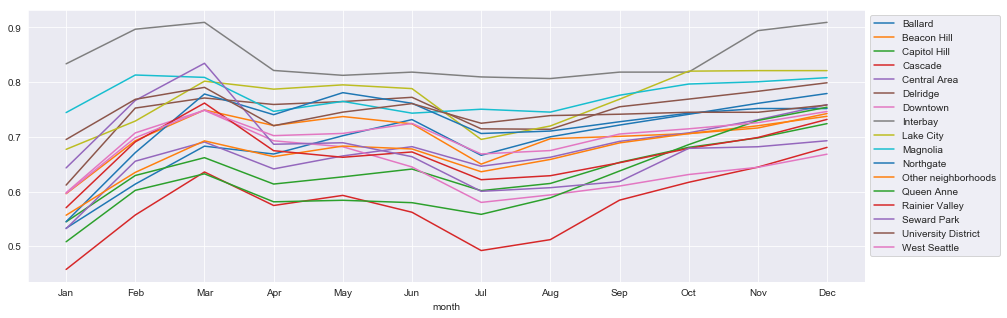

```python
fig, ax = plt.subplots(1,1, figsize =(15,5))
ax.set_xticks(list(range(1,13)))
ax.set_xticklabels(calendar.month_abbr[1:13])
pd.merge(s_cal, listings[['id','neighbourhood_group_cleansed']], left_on = 'listing_id', right_on = 'id').groupby(['month', 'neighbourhood_group_cleansed']).mean()['available'].unstack().plot(ax =ax)
ax.legend(bbox_to_anchor=(1,1), loc="upper left")
```

This is inline with the overall graphic as we saw above, The trend is almost likewise for all neighborhoods.

# Now lets move on to our second problem- look at the main factors that Drive the price for a property

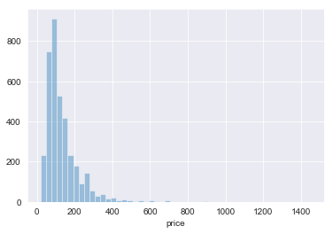

```python
# lets look at price variation in calendar da0ta
grouped_prices= s_cal.groupby('listing_id').median().round()
sns.set_style('darkgrid')
sns.distplot(grouped_prices['price'], hist=True, kde=False, bins=50 )
```

The above graph shows most of the listings have prices around 100 dollors and most of them lie between 0-300 dollors

```python
# Lets look at the distribution of prices accross neighborhood
listings.groupby('neighbourhood_group_cleansed').mean().sort_values('price', ascending = False)[['price']]
```

| neighbourhood_group_cleansed | price |
| --- | --- |
| Magnolia | 177.672131 |
| Queen Anne | 157.223729 |
| Downtown | 154.405660 |
| West Seattle | 141.359606 |
| Cascade | 140.101124 |
| Capitol Hill | 130.592593 |
| Central Area | 128.338753 |
| Ballard | 124.682609 |
| Other neighborhoods | 119.968514 |
| Interbay | 109.727273 |
| Seward Park | 108.477273 |
| Beacon Hill | 94.669492 |
| University District | 93.639344 |
| Lake City | 92.671642 |
| Rainier Valley | 91.899371 |
| Northgate | 88.550000 |
| Delridge | 83.278481 |

We can still see that places in central seattle are priced a little higher, which is quite expected again. Typically real estate prices and cost of living is higher closer to the city center and this is reflected in the data. But we got to consider other factors as well like beds, property type etc.

```python
def price_per_unit(price, units):
    if pd.isnull(units) or units == 0:
        return np.nan
    else:
        return price/units
listings['price_per_bedroom'] = listings.apply(lambda x: price_per_unit(x['price'],x['bedrooms']), axis = 1)
listings.groupby('neighbourhood_group_cleansed').mean().sort_values('price_per_bedroom', ascending = False)[['price_per_bedroom']]
```

| neighbourhood_group_cleansed | price_per_bedroom |
| --- | --- |
| Downtown | 129.413395 |
| Cascade | 113.896875 |
| Queen Anne | 109.114622 |
| Interbay | 102.909091 |
| Capitol Hill | 102.170668 |
| Magnolia | 101.028736 |
| West Seattle | 89.354497 |
| Central Area | 86.859012 |
| Ballard | 84.502701 |
| Other neighborhoods | 81.344013 |
| Seward Park | 72.252137 |
| University District | 71.910948 |
| Beacon Hill | 71.021829 |
| Lake City | 70.634921 |
| Rainier Valley | 68.333878 |
| Delridge | 67.438356 |
| Northgate | 67.093202 |

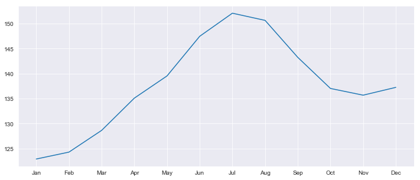

```python
# Seasonal variations of price

# First we check across the city and then at the neighbourhood level
fig, ax = plt.subplots(1,1, figsize =(12,5))
ax.set_xticks(list(range(1,13)))
ax.set_xticklabels(calendar.month_abbr[1:13])
# ax.set_xticks(['Jan' 'Feb', 'Mar', 'Apr', 'May', 'Jun', 'Jul', 'Aug', 'Sep', 'Oct', 'Nov', 'Dec'])

plt.plot( s_cal.groupby('month').mean().sort_values('month', ascending = True)['price'] )
```

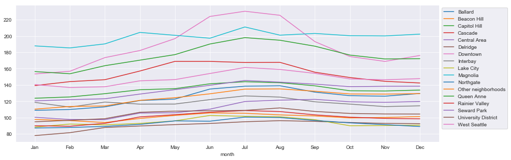

```python
fig, ax = plt.subplots(1,1, figsize =(15,5))
ax.set_xticks(list(range(1,13)))
ax.set_xticklabels(calendar.month_abbr[1:13])
pd.merge(s_cal, listings[['id','neighbourhood_group_cleansed']], left_on = 'listing_id', right_on = 'id').groupby(['month', 'neighbourhood_group_cleansed']).mean()['price'].unstack().plot(ax =ax)
ax.legend(bbox_to_anchor=(1,1), loc="upper left")
```

```python
listings.columns
```

```
Index(['id', 'host_is_superhost', 'property_type', 'room_type', 'accommodates',
       'bathrooms', 'bedrooms', 'amenities', 'price', 'number_of_reviews',
       'cancellation_policy', 'reviews_per_month',
       'neighbourhood_group_cleansed', 'price_per_bedroom'],
      dtype='object')
```

```python
#Removing all rows where price is NA as those are all listings when availability is false
s_cal.dropna(axis=0, inplace=True)
```

[output not shown]

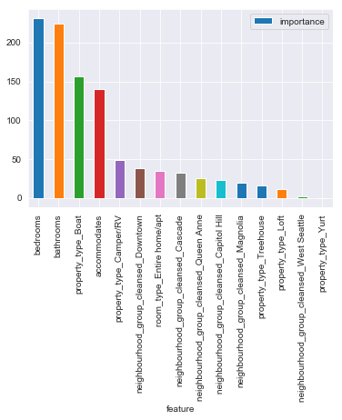

```python
# @title Features with most weight by Linear Regression

# prep data, normalise, one-hot
from sklearn import preprocessing
min_max_scaler = preprocessing.MinMaxScaler()

pd_model_data_x = listings[['neighbourhood_group_cleansed','property_type','room_type','accommodates','bathrooms','bedrooms']]
pd_model_data_x['accommodates'] = min_max_scaler.fit_transform(pd_model_data_x[['accommodates']])
pd_model_data_x['bathrooms'] = min_max_scaler.fit_transform(pd_model_data_x[['bathrooms']])
pd_model_data_x['bedrooms'] = min_max_scaler.fit_transform(pd_model_data_x[['bedrooms']])

pd_model_data_x = pd.get_dummies(pd_model_data_x, columns=['neighbourhood_group_cleansed','property_type','room_type'])
pd_model_data_y = listings['price']

# train and test - x and y
from sklearn.model_selection import train_test_split
X_train, X_test, y_train, y_test = train_test_split(pd_model_data_x,pd_model_data_y,test_size=0.2, random_state=42)

# linear regression
from sklearn.linear_model import LinearRegression
lm = LinearRegression()
lm.fit(X_train, y_train)

coefficients = pd.DataFrame({'feature': X_train.columns, 'importance': lm.coef_})
_ = coefficients.sort_values('importance', ascending=False)[:15].plot(x='feature', y='importance', kind='bar')
```

As we can see above the Most significant of the features in listings to give us price are bedrooms, bathrooms, property type, and accomodates.

Which is very correct because when these features are better and in abondance then the price will definately go up or down.

# Now lets move to the final Business question and using the above factors only we will try to create a prediction model to predict the price of a new listing.

```python
#Linear Regression
from sklearn import metrics
lm_mse = metrics.mean_squared_error(y_test, lm.predict(X_test))
lm_mse = np.sqrt(lm_mse)
print('Linear Regression MSE test: %.3f'% lm_mse)
print('Linear Regression R^2 test: %.3f, test: %.3f' % (
        r2_score(y_train, y_train_preds),
        r2_score(y_test, y_test_preds)))
```

[output not shown]

```python
#Train decision tree
from sklearn.tree import DecisionTreeRegressor
tree_reg = DecisionTreeRegressor()
tree_reg.fit(X_train, y_train)
```

```
DecisionTreeRegressor(criterion='mse', max_depth=None, max_features=None,
           max_leaf_nodes=None, min_impurity_decrease=0.0,
           min_impurity_split=None, min_samples_leaf=1,
           min_samples_split=2, min_weight_fraction_leaf=0.0,
           presort=False, random_state=None, splitter='best')
```

```python
des_tree_mse = metrics.mean_squared_error(y_test, tree_reg.predict(X_test))
des_tree_mse = np.sqrt(des_tree_mse)
print('Decision Tree MSE test: %.3f'% des_tree_mse)
print('Decision Tree R^2 test: %.3f' % (
        r2_score(y_test, y_test_preds)))
```

[output not shown]

```python
# train RF regressor model
from sklearn.ensemble import RandomForestRegressor
from sklearn.metrics import r2_score, mean_squared_error

forest = RandomForestRegressor(n_estimators=200,
                               max_features='sqrt',
                               criterion='mse',
                               random_state=42,
                               n_jobs=1)
forest.fit(X_train, y_train.squeeze())

#calculate scores for the model
y_train_preds = forest.predict(X_train)
y_test_preds = forest.predict(X_test)

print('Random Forest MSE train: %.3f, test: %.3f' % (
        np.sqrt(mean_squared_error(y_train, y_train_preds)),
        np.sqrt(mean_squared_error(y_test, y_test_preds))))
print('Random Forest R^2 train: %.3f, test: %.3f' % (
        r2_score(y_train, y_train_preds),
        r2_score(y_test, y_test_preds)))
```

```
Random Forest MSE train: 41.999, test: 57.012
Random Forest R^2 train: 0.784, test: 0.600
```

```python
import xgboost
xgb = xgboost.XGBRegressor(n_estimators=200, learning_rate=0.05, gamma=0.0,
                           colsample_bytree=0.2, max_depth=4)
xgb.fit(X_train,y_train)

#calculate and print scores for the model for top 15 features
y_train_preds = xgb.predict(X_train)
y_test_preds = xgb.predict(X_test)
```

```python
print('MSE train: %.3f, test: %.3f' % (
        np.sqrt(mean_squared_error(y_train, y_train_preds)),
        np.sqrt(mean_squared_error(y_test, y_test_preds))))
print('R^2 train: %.3f, test: %.3f' % (
        r2_score(y_train, y_train_preds),
        r2_score(y_test, y_test_preds)))
```

```
MSE train: 53.711, test: 55.135
R^2 train: 0.646, test: 0.625
```